# PoSI Case Study: Boston Housing

This file demonstrates PoSI on the Boston Housing data from Harrison Jr and Rubinfeld (1978) with amendments by Gilley, Pace, and others (1996). The original study intends to investigate the willingness to pay for clean by the “hedonic housing price equation” incorporating the level of air pollution, specifically the concentration of nitrogen oxides (NOX), as one attribute and concludes that “the valuation placed on a marginal improvement in air quality is quite sensitive to the specification of the hedonic housing value equation”. In other words, NOX is a significant factor to the housing price controlling other covariates. The final housing value equation is chosen as the best fit after comparing models with transformations of both the repsonse (Median value of house prices) and covariates, which invalidates the classical inference. After our post-selection adjustment to the inference, the conclusion that NOX is a significant factor at 0.05 level to the housing price controlling for other covariates still holds, but the Charles River dummy and racial diversity become insignificant.

# 1 The Boston housing data

The data description is as follows.

| Variable | Description |
| --- | --- |
| CRIM | crime rate |
| ZN | proportion of residential land zoned for lots over 25,000 sq. ft |
| INDUS | proportion of non-retail business acres |
| CHAS | Charles River dummy variable (=1 if tract bounds river; 0 otherwise) |
| NOX | nitrogen oxides concentration, pphm |
| RM | average number of rooms per dwelling |
| AGE | proportion of owner-occupied units built prior to 1940 |
| DIS | weighted distances to five Boston employment centers |
| RAD | index of accessibility to radial highways |
| TAX | full-value property tax rate per $10,000 |
| PTRATIO | pupil teacher ratio |
| B | 1000*(Bk-0.63)^2 where Bk is the proportion of blacks |
| LSTAT | percent lower status population |
| MEDV | median value of owner occupied homes in $1000’s |

```r
box.cox <- function(y, lambda=0) {
  if(lambda==0) log(y) else (y^lambda-1)/(lambda-1) }

power.trans <- function(y, lambda = 0) {
  if(lambda == 0) log(y) else y^lambda
}
```

```r
data <- read.table("boston.dat")

# https://spatial-statistics.com/pace_manuscripts/jeem_ms_dir/pdf/fin_jeem.pdf
data$MEDV[c(8,39,191,241,438,443,455,506)] <-
  c(22.1, 24.2, 33, 27, 8.2, 14.8, 14.4, 19)
data$LSTAT <- data$LSTAT/100


# the final model
fit <- lm(log(MEDV) ~
            I(RM^2) +
            AGE +
            I(log(DIS)) + I(log(RAD)) +
            TAX +
            PTRATIO +
            B +
            I(log(LSTAT)) +
            CRIM + ZN + INDUS + CHAS +
            I(box.cox(NOX, 2)),
          data)
# summary table of the final model
summary(fit)
```

```
##
## Call:
## lm(formula = log(MEDV) ~ I(RM^2) + AGE + I(log(DIS)) + I(log(RAD)) +
##     TAX + PTRATIO + B + I(log(LSTAT)) + CRIM + ZN + INDUS + CHAS +
##     I(box.cox(NOX, 2)), data = data)
##
## Residuals:
##      Min       1Q   Median       3Q      Max
## -0.70893 -0.09295 -0.01049  0.09575  0.79618
##
## Coefficients:
##                      Estimate Std. Error t value Pr(>|t|)
## (Intercept)         2.199e+00  1.348e-01  16.308  < 2e-16 ***
## I(RM^2)             6.255e-03  1.294e-03   4.833 1.80e-06 ***
## AGE                 7.100e-05  5.190e-04   0.137 0.891253
## I(log(DIS))        -1.978e-01  3.293e-02  -6.007 3.67e-09 ***
## I(log(RAD))         8.957e-02  1.887e-02   4.746 2.72e-06 ***
## TAX                -4.191e-04  1.210e-04  -3.464 0.000579 ***
## PTRATIO            -2.960e-02  4.944e-03  -5.986 4.14e-09 ***
## B                   3.611e-04  1.017e-04   3.551 0.000421 ***
## I(log(LSTAT))      -3.749e-01  2.466e-02 -15.200  < 2e-16 ***
## CRIM               -1.177e-02  1.228e-03  -9.590  < 2e-16 ***
## ZN                  9.175e-05  4.987e-04   0.184 0.854085
## INDUS               1.789e-04  2.331e-03   0.077 0.938846
## CHAS                9.213e-02  3.274e-02   2.813 0.005097 **
## I(box.cox(NOX, 2)) -6.372e-01  1.116e-01  -5.711 1.95e-08 ***
## ---
## Signif. codes:  0 '***' 0.001 '**' 0.01 '*' 0.05 '.' 0.1 ' ' 1
##
## Residual standard error: 0.1799 on 492 degrees of freedom
## Multiple R-squared:  0.8108, Adjusted R-squared:  0.8058
## F-statistic: 162.1 on 13 and 492 DF,  p-value: < 2.2e-16
```

```r
# summary table of the final model with sandwich
summ(fit, robust = "HC0")
```

| Observations | 506 |
| --- | --- |
| Dependent variable | log(MEDV) |
| Type | OLS linear regression |

| F(13,492) | 162.14 |
| --- | --- |
| R² | 0.81 |
| Adj. R² | 0.81 |

|  | Est. | S.E. | t val. | p |
| --- | --- | --- | --- | --- |
| (Intercept) | 2.20 | 0.13 | 16.35 | 0.00 |
| I(RM^2) | 0.01 | 0.00 | 3.20 | 0.00 |
| AGE | 0.00 | 0.00 | 0.13 | 0.90 |
| I(log(DIS)) | -0.20 | 0.04 | -5.19 | 0.00 |
| I(log(RAD)) | 0.09 | 0.02 | 5.06 | 0.00 |
| TAX | -0.00 | 0.00 | -3.81 | 0.00 |
| PTRATIO | -0.03 | 0.00 | -8.15 | 0.00 |
| B | 0.00 | 0.00 | 2.50 | 0.01 |
| I(log(LSTAT)) | -0.37 | 0.04 | -10.24 | 0.00 |
| CRIM | -0.01 | 0.00 | -5.19 | 0.00 |
| ZN | 0.00 | 0.00 | 0.25 | 0.80 |
| INDUS | 0.00 | 0.00 | 0.10 | 0.92 |
| CHAS | 0.09 | 0.03 | 2.64 | 0.01 |
| I(box.cox(NOX, 2)) | -0.64 | 0.12 | -5.33 | 0.00 |

Standard errors: Robust, type = HC0

# 2 PoSI

We provide PoSI adjustment considering the following transformations mentioned in the Harrison Jr and Rubinfeld (1978).

- Log transformation of the response `MEDV`;
- Grid search of Box-Cox transformation of the variable of interest `NOX`;
- Log/linear/quadratic transformation of `RM`.

Here are some model building procedures mentioned in the paper.

- Page 86, line 10

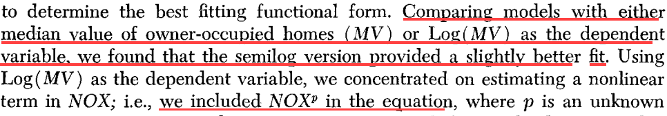

- Page 86, line -9

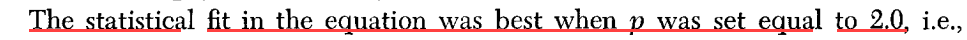

- Page 96, TABLE IV

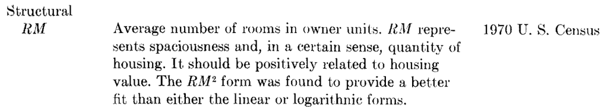

```r
x <- data[, 1:(ncol(data)-1)]
y <- data[, ncol(data)]

log_y <- log(y)
y_ <- cbind(y, log_y)

x$DIS <- log(x$DIS)
x$RAD <- log(x$RAD)
x$LSTAT <- log(x$LSTAT)

p <- ncol(x)
nboot <- 1000
```

```r
# grid search from 0 to 10 with 1000 grid points
nox_trans <- seq(0,10,length.out = 1000)
# log/linear/quadratic transformation for RM
rm_trans <- 0:2
combs <- t(expand.grid(nox_trans, rm_trans))

Hm <- matrix(0, nrow = ncol(combs), ncol = nboot)
Hs <- matrix(0, nrow = ncol(combs), ncol = nboot)

# for each variable, (maxk, nboot)
Hmp <- array(0, c(ncol(combs), nboot, p))
Hsp <- array(0, c(ncol(combs), nboot, p))

for(j in ncol(y_)) {
  for(i in 1:ncol(combs)) {
    if((i %% 500)==0) print(c(j,i))
    q <- combs[,i]
    x_ <- x
    x_$NOX <- box.cox(x$NOX, q[1])
    x_$RM <- power.trans(x$RM, q[2])

    tmp <- max_t_mul_boot_k(x_, y_[,j], p,
                            sandwich = T,
                            intercept = T,
                            Nboot = nboot,
                            force_in = 1:p,
                            individual = 1:p)



    Hs[i, ] <- pmax(Hs[i, ], colMax(tmp$BootSample))
    Hm[i, ] <- pmax(Hm[i, ], colMax(tmp$BootRank))

    Hsp[i,,] <- pmax(Hsp[i,,], t(tmp$BootSample1))
    Hmp[i,,] <- pmax(Hmp[i,,], t(tmp$BootRank1))
  }
}

# final model
x_ <- x
x_$NOX <- box.cox(x$NOX, 2)
# x_$NOX <- power.trans(x$NOX, 2)
x_$RM <- power.trans(x$RM, 2)

fit <- lm(log_y~as.matrix(x_))
se <- sqrt(diag(vcovHC(fit, "HC0")))[-1]
fit.ci <- summ(fit, confint = T)$coeftable[-1,]


# PoSI constant without prepivot
K <- get_T(Hm = Hs)
# PoSI constant with prepivot
K_norm <- get_T(x_, y_[,2], 1:p, 1, matrix(colMax(Hm), nrow = 1), maxk = 1, Nboot = nboot, intercept = T, adjust = T)
# PoSI1 constant with prepivot
K_norm1 <- sapply(1:p, function(i) get_T(x_, y_[,2], 1:p, 1, matrix(colMax(Hmp[,,i]),nrow=1), maxk = 1, Nboot = nboot, intercept = T, adjust = T))

# adjusted p
t.s <- coef(fit)[-1]/se
pval_norm <- get_p(t.s, x_, y_[,2], 1:p, 1, matrix(Hm_, nrow = 1), maxk = 1, Nboot = nboot, intercept = T, adjust = T)
pval_norm1 <- sapply(1:p, function(i) get_p(t.s[i], x_, y_[,2], 1:p, 1, matrix(colMax(Hmp[,,i]),nrow=1), maxk = 1, Nboot = nboot, intercept = T, adjust = T))

saveRDS(list(K_norm = K_norm, K_norm1 = K_norm1,
             pval_norm = pval_norm, pval_norm1 = pval_norm1),
        "boston_PoSI.RDS")
```

# 3 Report

After PoSI or PoSI1 adjustment, `RIVER` and `BLK` change from significant at 0.05 level to insignificant. The conclusion for the variable of interest `NOX` does not change.

| Variable | Unadjusted | Adjusted |
| --- | --- | --- |
| NOX | ✓ | ✓ |
| RM | ✓ | ✓ |
| AGE | ✗ | ✗ |
| CRIM | ✓ | ✓ |
| RES | ✗ | ✗ |
| INDUS | ✗ | ✗ |
| $\color{red}{\text{RIVER}}$ | ✓ | ✗ |
| TAX | ✓ | ✓ |
| PTR | ✓ | ✓ |
| $\color{red}{\text{BLK}}$ | ✓ | ✗ |
| LSTAT | ✓ | ✓ |
| DEMPC | ✓ | ✓ |
| DRADH | ✓ | ✓ |

```r
ret <- readRDS("boston_PoSI.RDS")
K_norm <- ret$K_norm; K_norm1 <- ret$K_norm1
pval_norm <- ret$pval_norm; pval_norm1 <- ret$pval_norm1

# final model
x_ <- x
x_$NOX <- box.cox(x$NOX, 2)
# x_$NOX <- power.trans(x$NOX, 2)
x_$RM <- power.trans(x$RM, 2)

fit <- lm(log_y~as.matrix(x_))
se <- sqrt(diag(vcovHC(fit, "HC0")))[-1]
fit.ci <- summ(fit, confint = T)$coeftable[-1,]

colnames(x) <- c("CRIM", "RES", "INDUS", "RIVER", "NOX",
                 "RM", "AGE", "DEMPC", "DRADH", "TAX",
                 "PTR", "BLK", "LSTAT")
colname_levels <- c("NOX", "RM", "AGE", "CRIM", "RES", "INDUS",
                    "RIVER", "TAX", "PTR", "BLK", "LSTAT", "DEMPC", "DRADH")
colname_labels <- c("NOX^2", "RM^2", "AGE", "CRIM", "RES", "INDUS",
                    "RIVER", "TAX", "PTR", "BLK", "logLSTAT", "logDEMPC", "logDRADH")

ret.p <-
  data.table(var = factor(colnames(x),
                          levels = colname_levels),
             pval_t = summ(fit)$coeftable[-1, 4],
             pval_adjust = pval_norm,
             pval_adjust1 = pval_norm1)
ret.ci <-
  data.table(var = factor(rep(colnames(x), 3),
                          levels = colname_levels),
             method = factor(rep(c("t", "adjust", "adjust1"),
                                 each = p),
                             levels = c("t", "adjust", "adjust1")),
             lower = c(fit.ci[,2],
                       # fit$coefficients[-1] - posi.k1 * se,
                       fit$coefficients[-1] - K_norm * se,
                       fit$coefficients[-1] - K_norm1 * se
             ),
             upper = c(fit.ci[,3],
                       # fit$coefficients[-1] + posi.k1 * se,
                       fit$coefficients[-1] + K_norm * se,
                       fit$coefficients[-1] + K_norm1 * se
             )
  )

# xtable(ret.ci)

ret.ci.wide <- dcast(ret.ci, var ~ method, value.var = c("lower", "upper"))
name.order <- 1
for(method in c("t","adjust", "adjust1")) {
  col.idx <- grep(paste0("^", method, "$"),
                  sapply(strsplit(names(ret.ci.wide), "_"), tail, 1))
  ret.ci.wide[, eval(method)] <-
    Reduce("*",
           ret.ci.wide[, col.idx,
                       with=F]) > 0
  # name.order <- c(name.order, col.idx, ncol(ret.ci.wide))
}
ret.ci.wide$K_t <- 1.96
ret.ci.wide$K_adjust <- K_norm
ret.ci.wide$K_adjust1 <- K_norm1
ret.ci.wide <- merge(ret.ci.wide, ret.p, by = "var")

for(method in c("t","adjust", "adjust1")) {
  col.idx <- grep(paste0("^", method, "$"),
                  sapply(strsplit(names(ret.ci.wide), "_"), tail, 1))
  name.order <- c(name.order, col.idx)
}
ret.ci.wide <- ret.ci.wide[,name.order,with=F]

changed.idx <- as.matrix(ret.ci.wide[, .SD, .SDcols = c("t", "adjust1")])
changed.idx[changed.idx] <- 1; changed.idx[!changed.idx] <- -1
changed.idx <- which(rowProds(changed.idx) != 1)
```

## 3.1 Inference with misspecification adjustment

```r
# the unadjusted with sandwich
kable(ret.ci.wide[, 1:6]) %>%
  kable_styling("striped", full_width = F) %>%
  row_spec(changed.idx, bold = T, color = "white", background = "#D7261E")
```

| var | lower_t | upper_t | t | K_t | pval_t |
| --- | --- | --- | --- | --- | --- |
| NOX | -0.8564776 | -0.4179994 | TRUE | 1.96 | 0.0000000 |
| RM | 0.0037122 | 0.0087978 | TRUE | 1.96 | 0.0000018 |
| AGE | -0.0009488 | 0.0010908 | FALSE | 1.96 | 0.8912534 |
| CRIM | -0.0141840 | -0.0093603 | TRUE | 1.96 | 0.0000000 |
| RES | -0.0008880 | 0.0010715 | FALSE | 1.96 | 0.8540850 |
| INDUS | -0.0044011 | 0.0047589 | FALSE | 1.96 | 0.9388462 |
| RIVER | 0.0277893 | 0.1564621 | TRUE | 1.96 | 0.0050972 |
| TAX | -0.0006568 | -0.0001814 | TRUE | 1.96 | 0.0005786 |
| PTR | -0.0393119 | -0.0198835 | TRUE | 1.96 | 0.0000000 |
| BLK | 0.0001613 | 0.0005609 | TRUE | 1.96 | 0.0004209 |
| LSTAT | -0.4233562 | -0.3264336 | TRUE | 1.96 | 0.0000000 |
| DEMPC | -0.2625420 | -0.1331322 | TRUE | 1.96 | 0.0000000 |
| DRADH | 0.0524897 | 0.1266428 | TRUE | 1.96 | 0.0000027 |

## 3.2 Simultaneous Inference with selection and misspecification adjustment

```r
# PoSI adjusted
kable(ret.ci.wide[, c(1, 7:11)]) %>%
  kable_styling("striped", full_width = F) %>%
  row_spec(changed.idx, bold = T, color = "white", background = "#D7261E")
```

| var | lower_adjust | upper_adjust | adjust | K_adjust | pval_adjust |
| --- | --- | --- | --- | --- | --- |
| NOX | -0.9953989 | -0.2790782 | TRUE | 2.996143 | 0.0000000 |
| RM | 0.0003967 | 0.0121134 | TRUE | 2.996143 | 0.0269730 |
| AGE | -0.0016280 | 0.0017700 | FALSE | 2.996143 | 1.0000000 |
| CRIM | -0.0185602 | -0.0049840 | TRUE | 2.996143 | 0.0000000 |
| RES | -0.0010177 | 0.0012012 | FALSE | 2.996143 | 1.0000000 |
| INDUS | -0.0050125 | 0.0053703 | FALSE | 2.996143 | 1.0000000 |
| RIVER | -0.0123991 | 0.1966506 | FALSE | 2.996143 | 0.1558442 |
| TAX | -0.0007484 | -0.0000899 | TRUE | 2.996143 | 0.0029970 |
| PTR | -0.0404663 | -0.0187291 | TRUE | 2.996143 | 0.0000000 |
| BLK | -0.0000708 | 0.0007930 | FALSE | 2.996143 | 0.2027972 |
| LSTAT | -0.4844447 | -0.2653451 | TRUE | 2.996143 | 0.0000000 |
| DEMPC | -0.3119639 | -0.0837104 | TRUE | 2.996143 | 0.0000000 |
| DRADH | 0.0365736 | 0.1425589 | TRUE | 2.996143 | 0.0000000 |

## 3.3 Marginal Inference with selection and misspecification adjustment

```r
# PoSI1 adjusted
kable(ret.ci.wide[, c(1, 12:16)]) %>%
  kable_styling("striped", full_width = F) %>%
  row_spec(changed.idx, bold = T, color = "white", background = "#D7261E")
```

| var | lower_adjust1 | upper_adjust1 | adjust1 | K_adjust1 | pval_adjust1 |
| --- | --- | --- | --- | --- | --- |
| NOX | -0.9968049 | -0.2776721 | TRUE | 2.897074 | 0.0000000 |
| RM | 0.0004308 | 0.0120793 | TRUE | 2.978705 | 0.0179820 |
| AGE | -0.0016224 | 0.0017644 | FALSE | 2.985806 | 1.0000000 |
| CRIM | -0.0183357 | -0.0052085 | TRUE | 2.961408 | 0.0000000 |
| RES | -0.0010112 | 0.0011948 | FALSE | 3.007905 | 1.0000000 |
| INDUS | -0.0049946 | 0.0053524 | FALSE | 2.978705 | 1.0000000 |
| RIVER | -0.0111873 | 0.1954388 | FALSE | 2.986222 | 0.1368631 |
| TAX | -0.0007446 | -0.0000937 | TRUE | 2.978705 | 0.0049950 |
| PTR | -0.0404288 | -0.0187666 | TRUE | 2.951015 | 0.0000000 |
| BLK | -0.0000598 | 0.0007820 | FALSE | 2.961408 | 0.1628372 |
| LSTAT | -0.4827946 | -0.2669952 | TRUE | 2.985806 | 0.0000000 |
| DEMPC | -0.3112997 | -0.0843746 | TRUE | 2.919752 | 0.0000000 |
| DRADH | 0.0373718 | 0.1417607 | TRUE | 2.951015 | 0.0000000 |

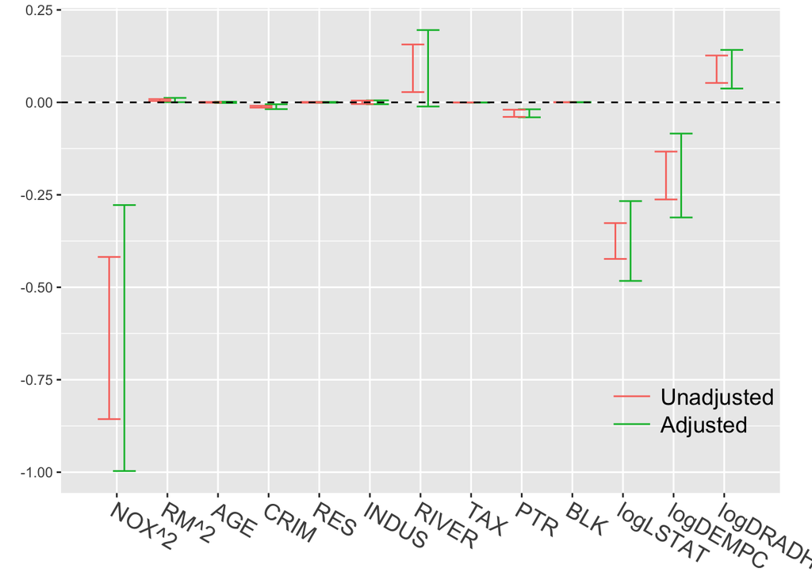

```r
ret.ci %>%
  filter(method %in% c("t", "adjust1")) %>%
  ggplot(aes(x = var, col = method)) +
  geom_errorbar(aes(ymin = lower, ymax = upper), position=position_dodge(0.6)) +
  geom_hline(yintercept = 0, linetype = "dashed") +
  scale_color_manual(values = hue_pal()(3),
                     labels = c("Unadjusted", "Adjusted")) +
  scale_x_discrete(labels = colname_labels) +
  xlab("") +
  ylab("") +
  theme(legend.key=element_blank(),
        legend.key.width = unit(1,"cm"),
        legend.background=element_blank(),
        # legend.position = c(0.02, 0.10),
        legend.position = c(0.75, 0.18),
        legend.direction = "vertical",
        legend.justification="left",
        legend.spacing.x = unit(0.05, 'in'),
        legend.title = element_blank(),
        legend.text = element_text(size = 14),
        axis.text.x = element_text(size = 14, angle = -30, hjust = -.01),
        plot.margin = margin(t = 5, b = -10, r = 20)) +
  coord_cartesian(xlim = c(.5,13.5))
```

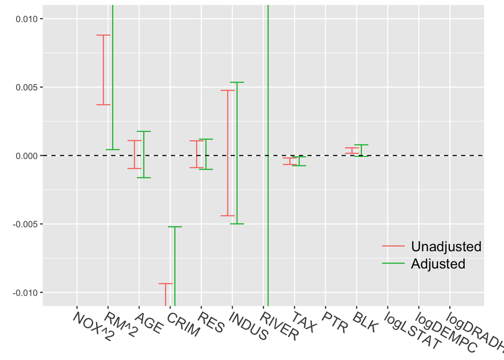

```r
ret.ci %>%
  filter(method %in% c("t", "adjust1")) %>%
  ggplot(aes(x = var, col = method)) +
  geom_errorbar(aes(ymin = lower, ymax = upper), position=position_dodge(0.6)) +
  geom_hline(yintercept = 0, linetype = "dashed") +
  scale_color_manual(values = hue_pal()(3),
                     labels = c("Unadjusted", "Adjusted")) +
  scale_x_discrete(labels = colname_labels) +
  xlab("") +
  ylab("") +
  theme(legend.key=element_blank(),
        legend.key.width = unit(1,"cm"),
        legend.background=element_blank(),
        legend.position = c(0.75, 0.18),
        legend.direction = "vertical",
        legend.justification="left",
        legend.spacing.x = unit(0.05, 'in'),
        legend.title = element_blank(),
        legend.text = element_text(size = 14),
        axis.text.x = element_text(size = 14,
                                   angle = -30,
                                   hjust = -.01),
        plot.margin = margin(t = 5, b = -10, r = 20)) +
  coord_cartesian(xlim = c(.5,13.5), ylim=c(-.01, .01))
```

Gilley, Otis W, R Kelley Pace, and others. 1996. “On the Harrison and Rubinfeld Data.” *Journal of Environmental Economics and Management* 31 (3): 403–5.

Harrison Jr, David, and Daniel L Rubinfeld. 1978. “Hedonic Housing Prices and the Demand for Clean Air.” *Journal of Environmental Economics and Management* 5 (1): 81–102.